# Homework Assignment 4

# Problem 4 : Sentimental Analysis witn *nrc* lexicon (20 points)

- dataset: lyrics

### (To-Do, 10 points) Q4-1, maroon 5’s song

- Step1: filter the song of maroon 5 (using “maroon 5”, case sensitive)
- Step2: tokenization
- Step3: remove stopwords
- Step4: show the result with head (10 points)

```r
maroon.5 <- lyrics %>%
  filter(Artist == "maroon 5") %>%
  unnest_tokens(word, Lyrics) %>%
  anti_join(stop_words)
head(maroon.5)
```

| Rank | Song | Artist | word |
| --- | --- | --- | --- |
| 5 | sugar | maroon 5 | im |
| 5 | sugar | maroon 5 | hurting |
| 5 | sugar | maroon 5 | baby |
| 5 | sugar | maroon 5 | im |
| 5 | sugar | maroon 5 | broken |
| 5 | sugar | maroon 5 | loving |

- not for score, but just showing top words in their song

```r
maroon.5 %>%
  group_by(word) %>%
  summarise(uses = n()) %>%
  arrange(desc(uses))
```

| word | uses |
| --- | --- |
| animals | 20 |
| im | 18 |
| lie | 18 |
| yeah | 16 |
| dont | 14 |
| ny | 12 |
| sugar | 10 |
| love | 9 |
| baby | 8 |
| wanna | 8 |

[output cut: 94 more lines]

### (To-Do, 10 point) Q4-2 Sentimental analysis with *nrc* lexicon

- nrc lexicon contains 8 emotions (anger, fear, anticipation, trust, surprise, sadness, joy, and disgust) and 2 sentiments (negative or positive)
- Step 1: mapping each token with nrc lexicon
- Step 2: grouping word by each sentiment dimension
- Step 3: count number of word per sentiment dimension
- Step 4: show the result in “trust”,“joy”,“surprise”,“anticipation” sentiment dimension only (10 point)

```r
maroon.5_words <- maroon.5 %>%
  inner_join(get_sentiments("nrc")) %>%
  group_by(sentiment, word) %>%
  count(mycount = n()) %>%
  distinct() %>%
  filter(sentiment %in%
           c("trust", "joy", "surprise", "anticipation"))
head(maroon.5_words)
```

| sentiment | word | mycount | n |
| --- | --- | --- | --- |
| anticipation | alive | 291 | 5 |
| anticipation | start | 291 | 2 |
| anticipation | sweet | 291 | 1 |
| anticipation | wont | 291 | 8 |
| joy | alive | 291 | 5 |
| joy | baby | 291 | 8 |

- This is not for score; however, showing the correct results with graph.

[figure not shown]

```r
ggplot(data = maroon.5_words, aes(label = word)) +
  ggrepel::geom_label_repel(
    aes(x = word, y = rnorm(nrow(maroon.5_words)),
        label = word),
    direction = "both",
    box.padding = 0.04,
    segment.color = "transparent",
    size = 3) +
  facet_wrap(~sentiment, ncol = 2) +
  labs(x = "", y = "") +
  theme(axis.text.y = element_blank(),
        axis.text.x = element_blank(),
        axis.ticks = element_blank(),
        panel.grid = element_blank(),
        panel.background = element_blank())
```

# Q5 (20point) Word cloud

```r
# install.packages('wordcloud')
library(wordcloud)
```

### (To-Do, 10 point) Q5-1 : word cloud

- Goal: showing the word cloud based on word count
- step 1: removing stop_words
- step 2; count each word
- step 3: show *wordcloud* method with the word that appears more than 100 times (ie., max.words=100) (10 points)

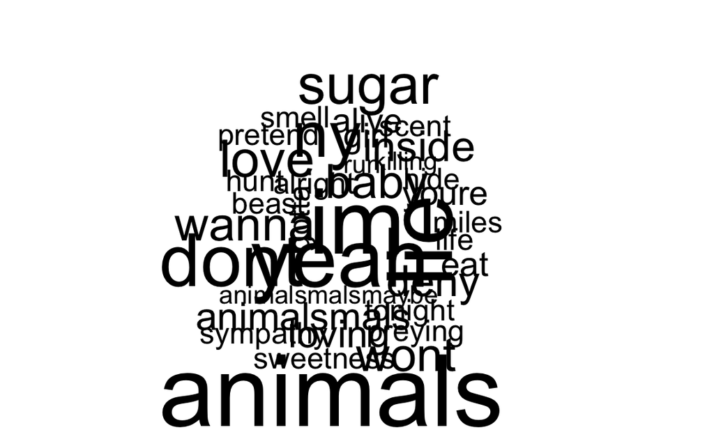

```r
maroon.5_wordcloud <- maroon.5 %>%
  anti_join(stop_words, by = "word") %>%
  count(word) %>%
  with(wordcloud(word, n, max.words=100))
```

### (To-Do, 10 point) Q5-2: word cloud with *bing* lexicon

```r
library(reshape2)
```

- Step 1: mapping each token in maroon.5 with bing’s lexicon sentiment (positive vs negative)
- Step 2: count each word per each sentiment
- Step 3: apply acast in reshape method
- Step 4: comparison.cloud methods to show positive and negative words with different colors (red and blue), (10 points)
- Hint: What are the biggest red words? Yes, it should be Love and loving!

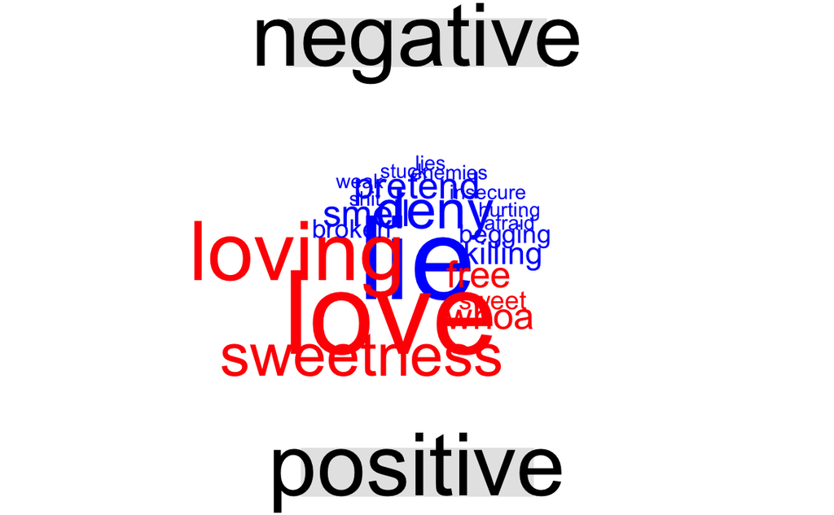

```r
maroon.5_wordcloud_sentiment <- maroon.5 %>%
  inner_join(get_sentiments("bing"), by = "word") %>%
  group_by(sentiment) %>%
  count(word) %>%
  acast(word~sentiment, value.var ="n", fill=0) %>%
  comparison.cloud(colors = c("blue","red"), max.words = 100)
```